# Reproducible Research Project 1

```r
library(dplyr)
library(mice)
library(ggplot2)
```

## Loading and preprocessing the data

In this step, I’ll be loading the dataset and performing basic preprocessing on it so that it can be used for further analysis

```r
activity <- read.csv("activity.csv")
activity <- transform(activity, date = as.Date(date))
head(activity)
```

```
##   steps       date interval
## 1    NA 2012-10-01        0
## 2    NA 2012-10-01        5
## 3    NA 2012-10-01       10
## 4    NA 2012-10-01       15
## 5    NA 2012-10-01       20
## 6    NA 2012-10-01       25
```

## What is mean total number of steps taken per day?

To find the mean number of steps per day, first we group the dataset using `dplyr` package and then summarise the data by finding mean number of steps per day

```r
activity_sub <- subset(activity, !is.na(steps))
activity_by_day <- group_by(activity_sub, date)
activity_by_day <- summarise(activity_by_day, total_steps = sum(steps))
head(activity_by_day)
```

```
## # A tibble: 6 x 2
##   date       total_steps
##   <date>           <int>
## 1 2012-10-02         126
## 2 2012-10-03       11352
## 3 2012-10-04       12116
## 4 2012-10-05       13294
## 5 2012-10-06       15420
## 6 2012-10-07       11015
```

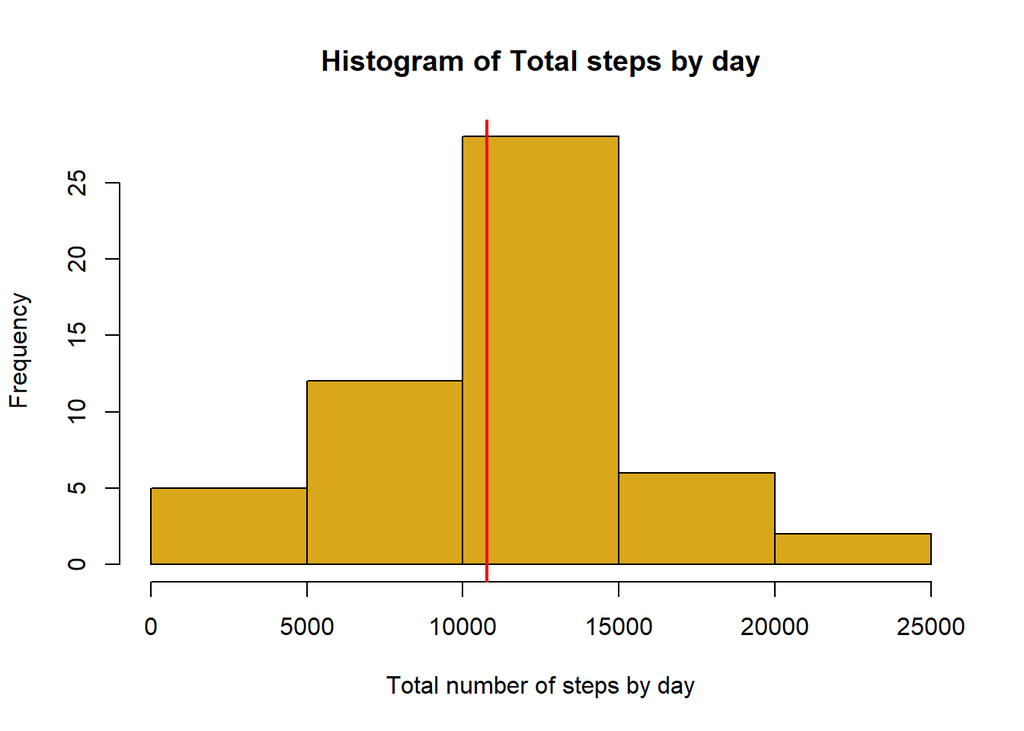

```r
with(activity_by_day, hist(total_steps, col = "#d9a61c", xlab = "Total number of steps by day", main = "Histogram of Total steps by day"))
abline(v = mean(activity_by_day$total_steps), lw = 2, col = "red")
```

```r
cat("The mean number of steps per day are: ",mean(activity_by_day$total_steps))
```

```
## The mean number of steps per day are:  10766.19
```

```r
cat("The median number of steps per day are: ",median(activity_by_day$total_steps))
```

```
## The median number of steps per day are:  10765
```

Since mean and median values are very close, they are represented by the same vertical red line in the graph.

## What is the average daily activity pattern?

First the data has to be prepared in order to do analysis on daily activity pattern. Therefore, the data is grouped by 5 minute interval labels and then it is summarised by finding average number of steps per 5 minute time label, averaged across all the days.

```r
activity_by_interval <- group_by(activity_sub, interval)
activity_by_interval <- summarise(activity_by_interval, mean_steps = mean(steps))
head(activity_by_interval)
```

```
## # A tibble: 6 x 2
##   interval mean_steps
##      <int>      <dbl>
## 1        0     1.72
## 2        5     0.340
## 3       10     0.132
## 4       15     0.151
## 5       20     0.0755
## 6       25     2.09
```

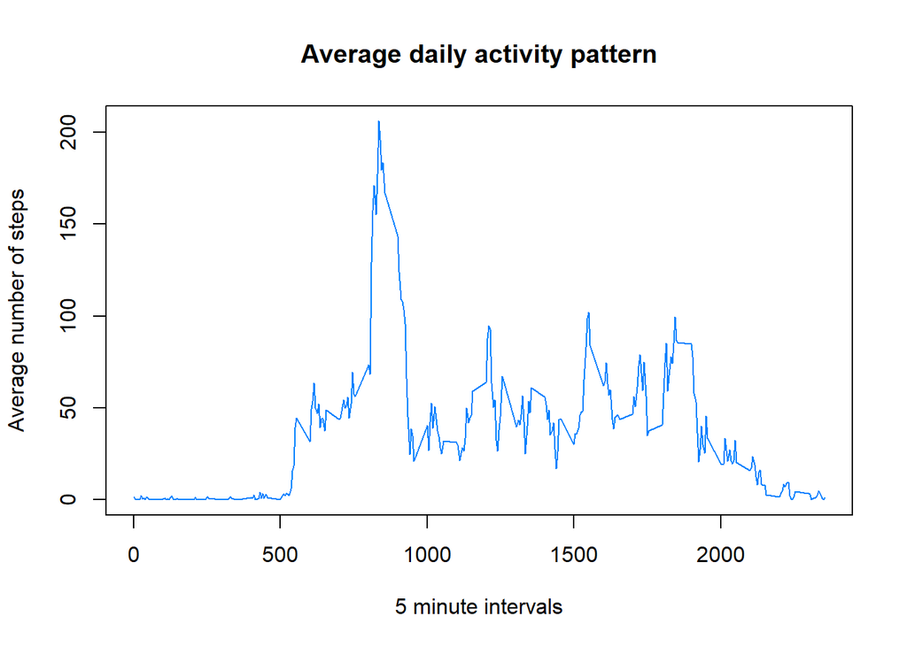

```r
with(activity_by_interval, plot(interval, mean_steps, type='l', col = "#0080FF", xlab = "5 minute intervals", ylab = "Average number of steps", main = "Average daily activity pattern"))
```

The 5 minute interval having maximum number of steps can be found as:

```r
activity_by_interval[activity_by_interval$mean_steps == max(activity_by_interval$mean_steps),]
```

```
## # A tibble: 1 x 2
##   interval mean_steps
##      <int>      <dbl>
## 1      835       206.
```

Thus, the 5 minute interval labeled by `835` has the maximum number of steps on average, which satisfies the pattern shown in the plot.

## Imputing missing values

```r
sum(is.na(activity))
```

```
## [1] 2304
```

This shows the number of missing values in the dataset.

```r
imp <- mice(activity, where = is.na(activity))
imputed_activity <- complete(imp)
sum(is.na(imputed_activity))
```

```
## [1] 0
```

Using the mice package to perform imputations. After the process is complete, it can be seen that there are zero missing values.

## Histogram of the total number of steps after imputing data

After imputing the data, we can create another histogram to see things more clearly.

```r
by_day <- group_by(imputed_activity, date)
by_day <- summarise(by_day, total_steps = sum(steps))
```

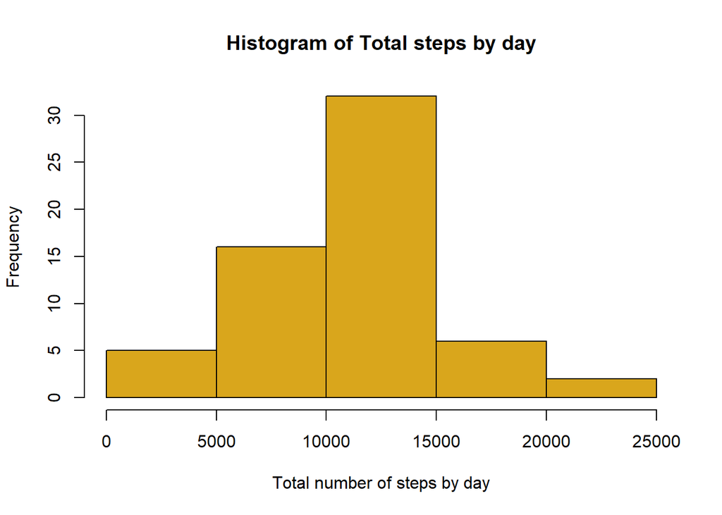

```r
with(by_day, hist(total_steps, col = "#d9a61c", xlab = "Total number of steps by day", main = "Histogram of Total steps by day"))
```

## Are there differences in activity patterns between weekdays and weekends?

To perform this analysis, first the data has to be prepared.

```r
imputed_activity <- transform(imputed_activity, day_factor = factor(ifelse(weekdays(date) %in% c("Saturday","Sunday"), "weekend","weekday")))
head(imputed_activity)
```

```
##   steps       date interval day_factor
## 1     0 2012-10-01        0    weekday
## 2     0 2012-10-01        5    weekday
## 3    47 2012-10-01       10    weekday
## 4     0 2012-10-01       15    weekday
## 5     0 2012-10-01       20    weekday
## 6     0 2012-10-01       25    weekday
```

To calculate average number of steps, average across weekdays or weekends, the data has to be grouped on the basis of two attributes, `interval` and `day_factor`.

```r
grouped <- group_by(imputed_activity, interval, day_factor)
grouped <- summarise(grouped, avg_steps = mean(steps))
head(grouped)
```

```
## # A tibble: 6 x 3
## # Groups:   interval [3]
##   interval day_factor avg_steps
##      <int> <fct>          <dbl>
## 1        0 weekday         2.02
## 2        0 weekend         0
## 3        5 weekday         2.49
## 4        5 weekend         0
## 5       10 weekday         1.2
## 6       10 weekend         2.94
```

Now the plot can be made.

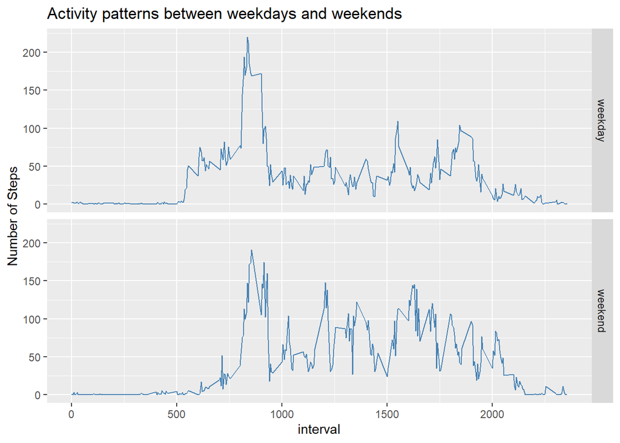

```r
g <- ggplot(grouped, aes(x = interval, y = avg_steps))
g + geom_line(color='steelblue') + facet_grid(day_factor ~ .) + labs(title = "Activity patterns between weekdays and weekends", y = "Number of Steps")
```